# More Statistical Tests for Two Variables

Fiona

This tutorial is based on [Javier Rasero’s](https://github.com/jrasero/cm-85309-2023) prior 309 course content.

## Two categorical variables

### $X^2$ Test For Independence

The $X^2$ test for independence is a statistical test based on the $X^2$ statistic, which compares the observed frequencies in a contingency table with the expected frequencies under the assumption that the two variables are independent. In this tutorial, we will learn how to perform the $X^2$ test for independence in R.

We’ll use some simulated data on the results from a clinical trial. Participants received either a drug or a placebo, and their progress was monitored. At the end of the study, it was determined whether the participants’ progress had worsened, remained the same, or improved.

```r
dat.tutorial<-read.csv("https://raw.githubusercontent.com/jrasero/cm-85309-2023/main/datasets/tutorial8chisquare.csv")
head(dat.tutorial)
```

```
##     group evolution
## 1 Placebo     Worse
## 2 Placebo     Worse
## 3 Placebo     Worse
## 4 Placebo     Worse
## 5 Placebo     Worse
## 6 Placebo     Worse
```

**Comprehension Check:**

**1) What is the null hypothesis for the *one-sample* chi-square test that we learned previously?**

**2) What is the null hypothesis for a $X^2$ Test for Independence?**

Just like our one-sample chi-square test, we need to start with a frequency table:

```r
myTable <- table(dat.tutorial)
myTable
```

```
##          evolution
## group     Better Same Worse
##   Drug        30   28    11
##   Placebo     25   44    33
```

Note that if our dataset had more than two variables, we’d need to specify which variables we want in the table. For example:

```r
table(dat.tutorial$group, dat.tutorial$evolution)
```

```
##
##           Better Same Worse
##   Drug        30   28    11
##   Placebo     25   44    33
```

#### Prop tables

If we want to understand the *proportions* within our table, we can use `prop.table()`. This can give you a better idea of potential differences across your distributions.

The proportions will always add to 1:

```r
prop.table(myTable)
```

```
##          evolution
## group         Better       Same      Worse
##   Drug    0.17543860 0.16374269 0.06432749
##   Placebo 0.14619883 0.25730994 0.19298246
```

```r
sum(prop.table(myTable))
```

```
## [1] 1
```

You may want to specifically compare proportions within certain groups. To do so, you can use the `margins` argument. For example, if we were interested in the proportion of each outcome *within* each treatment condition, we could do:

```r
marg1 <- prop.table(myTable, margin = 1)
marg1
```

```
##          evolution
## group        Better      Same     Worse
##   Drug    0.4347826 0.4057971 0.1594203
##   Placebo 0.2450980 0.4313725 0.3235294
```

```r
#each row sums to 1:
sum(marg1[1,]) #sum of Drug row
```

```
## [1] 1
```

```r
sum(marg1[2,]) #sum of Placebo row
```

```
## [1] 1
```

Alternatively, if we were interested in the proportion of treatment assignment within each outcome:

```r
marg2 <- prop.table(myTable, margin = 2)
marg2
```

```
##          evolution
## group        Better      Same     Worse
##   Drug    0.5454545 0.3888889 0.2500000
##   Placebo 0.4545455 0.6111111 0.7500000
```

```r
# each column sums to 1
sum(marg2[,1])
```

```
## [1] 1
```

```r
sum(marg2[,2])
```

```
## [1] 1
```

```r
sum(marg2[,3])
```

```
## [1] 1
```

#### Running the test

To run the test, we use the same function that we did previously. The only difference is that our frequency table now has information on two categorical variables instead of one.

**Important: Note that you input your frequency table, not your prop table. Why?**

```r
test1 <- chisq.test(myTable)
test1
```

```
##
##  Pearson's Chi-squared test
##
## data:  myTable
## X-squared = 8.976, df = 2, p-value = 0.01124
```

**Comprehension Check: What conclusion do you draw from this test?**

To better understand exactly what the association is here, you should look at the observed and expected frequencies.

The observed frequencies are the same as our frequency table, but can be extracted from the test like so:

```r
test1$observed
```

```
##          evolution
## group     Better Same Worse
##   Drug        30   28    11
##   Placebo     25   44    33
```

And the test computes the expected frequencies – i.e., the number of observations in each cell if the drug and placebo groups had the same distribution of outcomes:

```r
test1$expected
```

```
##          evolution
## group       Better     Same    Worse
##   Drug    22.19298 29.05263 17.75439
##   Placebo 32.80702 42.94737 26.24561
```

It may be easier to turn these frequency tables into prop tables when interpreting differences. Here, I choose margin = 1 because we’re probably most interested in differences between the two treatment conditions.

```r
#observed proportions
prop.table(test1$observed, margin = 1)
```

```
##          evolution
## group        Better      Same     Worse
##   Drug    0.4347826 0.4057971 0.1594203
##   Placebo 0.2450980 0.4313725 0.3235294
```

```r
#expected proportions
prop.table(test1$expected, margin = 1)
```

```
##          evolution
## group        Better      Same     Worse
##   Drug    0.3216374 0.4210526 0.2573099
##   Placebo 0.3216374 0.4210526 0.2573099
```

**Comprehension checks:**

**What conclusion do you draw based on our test output and these two tables?**

### Fisher’s exact test

$X^2$ Tests are not recommended for small sample sizes, for example when there are fewer than 5 observations expected in each cell. For these cases, it is recommended to use Fisher’s exact test. This test computes the probability of observing a particular table given the marginal totals:

$$p = \frac{\left( a + b \right)! \left( c
+ d \right)! \left( a + c \right)! \left( b + d \right)!}{a! b! c! d!
\left( a + b + c + d \right)!}$$

The null hypothesis of Fisher’s exact test is that there is no association between the two variables. **Note that this test can only be used with 2 x 2 frequency tables.** (E.g., two binary variables.)

Let’s create a sample frequency table:

```r
fisher.table<-matrix(c(5,1, 2,7), nrow=2, byrow=TRUE)

colnames(fisher.table)<-c("A", "B")
rownames(fisher.table)<-c("a", "b")
fisher.table
```

```
##   A B
## a 5 1
## b 2 7
```

```r
res.chisq<-chisq.test(fisher.table)
res.chisq
```

```
##
##  Pearson's Chi-squared test with Yates' continuity correction
##
## data:  fisher.table
## X-squared = 3.2254, df = 1, p-value = 0.0725
```

Let’s instead run a Fisher’s test. In order to perform this kind of test in R, you can use the `fisher.test()` function, which also takes a frequency table as its input and returns the p-value of the test, as well as the odds ratio and its confidence interval.

```r
res.fisher<-fisher.test(fisher.table)
res.fisher
```

```
##
##  Fisher's Exact Test for Count Data
##
## data:  fisher.table
## p-value = 0.04056
## alternative hypothesis: true odds ratio is not equal to 1
## 95 percent confidence interval:
##    0.8646648 934.0087368
## sample estimates:
## odds ratio
##   13.59412
```

**Comprehension Check: What conclusion do you draw from this output?**

### McNemar Test

If your data are **paired** you can use a McNemar Test to compare to binary outcomes. (Just like Fisher’s, you can only do this test with a 2 x 2 frequency table.) It is based on a different distribution (binomial) than Fishers (which is hypergeometric).

**Comprehension Check: What does it mean for data to be paired? What other test did we learn that requires this characteristic of the data?**

We can simulate a data set:

```r
table.mcnemar <- matrix(c(5, 3, 12, 3), nrow = 2, byrow = TRUE)
colnames(table.mcnemar) <- c("Yes", "No")
rownames(table.mcnemar) <- c("Before", "After")

table.mcnemar
```

```
##        Yes No
## Before   5  3
## After   12  3
```

And perform the test using `mcnemar.test()`:

```r
# run the McNemar test
res.mcnemar <- mcnemar.test(table.mcnemar)

# Print the summary of running this test
res.mcnemar
```

```
##
##  McNemar's Chi-squared test with continuity correction
##
## data:  table.mcnemar
## McNemar's chi-squared = 4.2667, df = 1, p-value = 0.03887
```

## Two Continuous Variables

### Pearson’s Correlation

Pearson’s correlation is one of the most common types of statistical tests. It assesses the relationship between two continuous variables. For example, you might be interested in the correlation between a measure of loneliness, rated on a scale from 1 to 10, and a continuous measure of cardiovascular health.

Let’s simulate some data to illustrate:

```r
set.seed(1234)
x<-rnorm(50)
y<- 0.1*x + rnorm(50, sd = .3)
z<- -.2*x + rnorm(50, sd = .2)

dat.tutorial<-data.frame(x,y,z)
head(dat.tutorial)
```

```
##            x            y           z
## 1 -1.2070657 -0.662515952  0.32431786
## 2  0.2774292 -0.146879853 -0.15042954
## 3  1.0844412 -0.224222770 -0.20368954
## 4 -2.3456977 -0.539058373  0.36864398
## 5  0.4291247 -0.005780388 -0.25102466
## 6  0.5060559  0.219522335 -0.06781332
```

Before performing any correlation test, it is always recommended to visualize the relationship between the two variables using a scatterplot. As usual, we can use ggplot for this task.

Correlations assess *linear* relationships between to variables. So we’ll take advantage of the “lm” (“linear model”) method in `geom_smooth()`.

```r
library(tidyverse)
```

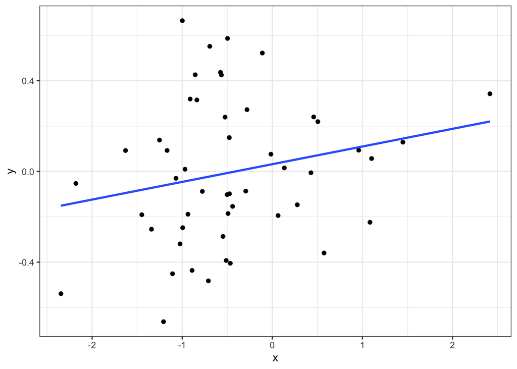

```r
ggplot(data=dat.tutorial, mapping=aes(x,y)) +
geom_point() +
geom_smooth(method = "lm",  se = FALSE) +
theme_bw()
```

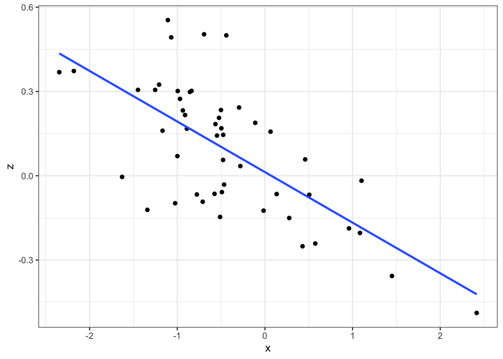

```r
ggplot(data=dat.tutorial, mapping=aes(x,z)) +
geom_point() +
geom_smooth(method = "lm",  se = FALSE) +
theme_bw()
```

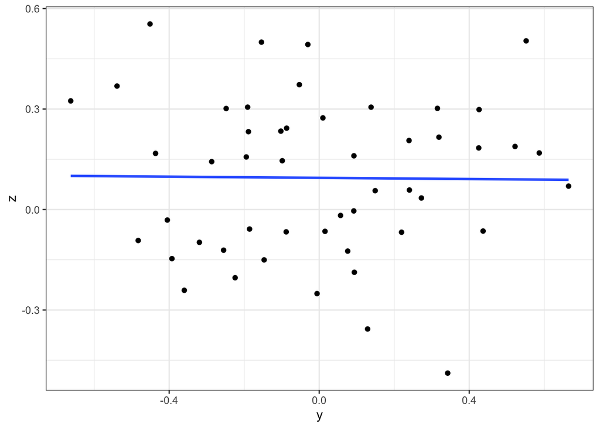

```r
ggplot(data=dat.tutorial, mapping=aes(y,z)) +
geom_point() +
geom_smooth(method = "lm",  se = FALSE) +
theme_bw()
```

**Comprehension Check: Which variables do you think will have a significant correlation?**

Let’s address find out using the cor.test function. Per usual, this default alpha level for this test is .05.

```r
cor.xy <- cor.test(dat.tutorial$x, dat.tutorial$y)
cor.xy
```

```
##
##  Pearson's product-moment correlation
##
## data:  dat.tutorial$x and dat.tutorial$y
## t = 1.5402, df = 48, p-value = 0.1301
## alternative hypothesis: true correlation is not equal to 0
## 95 percent confidence interval:
##  -0.06528645  0.46713615
## sample estimates:
##       cor
## 0.2170048
```

Equivalently, you can specify this function using formulas, although the structure is a bit different from what we’ve seen:

```r
res.xy<-cor.test(formula = ~ x + y, data = dat.tutorial)
res.xy
```

```
##
##  Pearson's product-moment correlation
##
## data:  x and y
## t = 1.5402, df = 48, p-value = 0.1301
## alternative hypothesis: true correlation is not equal to 0
## 95 percent confidence interval:
##  -0.06528645  0.46713615
## sample estimates:
##       cor
## 0.2170048
```

Now lets test x and z:

```r
res.xz <- cor.test(dat.tutorial$x, dat.tutorial$z)
res.xz
```

```
##
##  Pearson's product-moment correlation
##
## data:  dat.tutorial$x and dat.tutorial$z
## t = -6.4401, df = 48, p-value = 5.314e-08
## alternative hypothesis: true correlation is not equal to 0
## 95 percent confidence interval:
##  -0.8063683 -0.4965959
## sample estimates:
##        cor
## -0.6808344
```

To see the additional information stored in our `res.xz` object, we can look at:

```r
names(res.xz)
```

```
## [1] "statistic"   "parameter"   "p.value"     "estimate"    "null.value"
## [6] "alternative" "method"      "data.name"   "conf.int"
```

We can extract each of these elements with $:

```r
# the correlation coefficient
res.xz$estimate
```

```
##        cor
## -0.6808344
```

```r
#the t-statistic
res.xz$statistic
```

```
##         t
## -6.440084
```

**Comprehension check: Why do we have a t-statistic here, when we didn’t run a t-test? What does this statistic tell us?**

### A note on interpreting correlation coefficients

Run the below code, where we simulate some new variables and plot them:

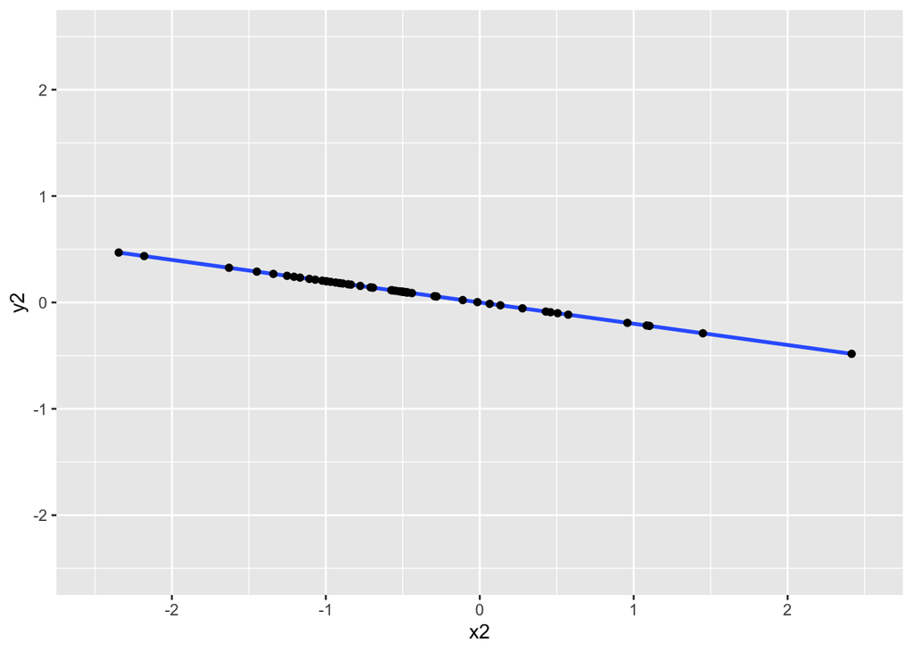

```r
set.seed(1234)
x2<-rnorm(50)
y2<- -.2*x2

dat.tutorial2 <- data.frame(x2,y2)

ggplot(dat.tutorial2, aes(x = x2, y = y2)) +
  geom_smooth(method = "lm") + geom_point() +
  xlim(-2.5, 2.5) +
  ylim(-2.5, 2.5)
```

**Comprehension check: Based on this plot, what do you expect the correlation coefficient to be?**

```r
cor.test(dat.tutorial2$x2, dat.tutorial2$y2)
```

```
##
##  Pearson's product-moment correlation
##
## data:  dat.tutorial2$x2 and dat.tutorial2$y2
## t = -Inf, df = 48, p-value < 2.2e-16
## alternative hypothesis: true correlation is not equal to 0
## 95 percent confidence interval:
##  -1 -1
## sample estimates:
## cor
##  -1
```

Now run this code. What do you expect the correlation to be?

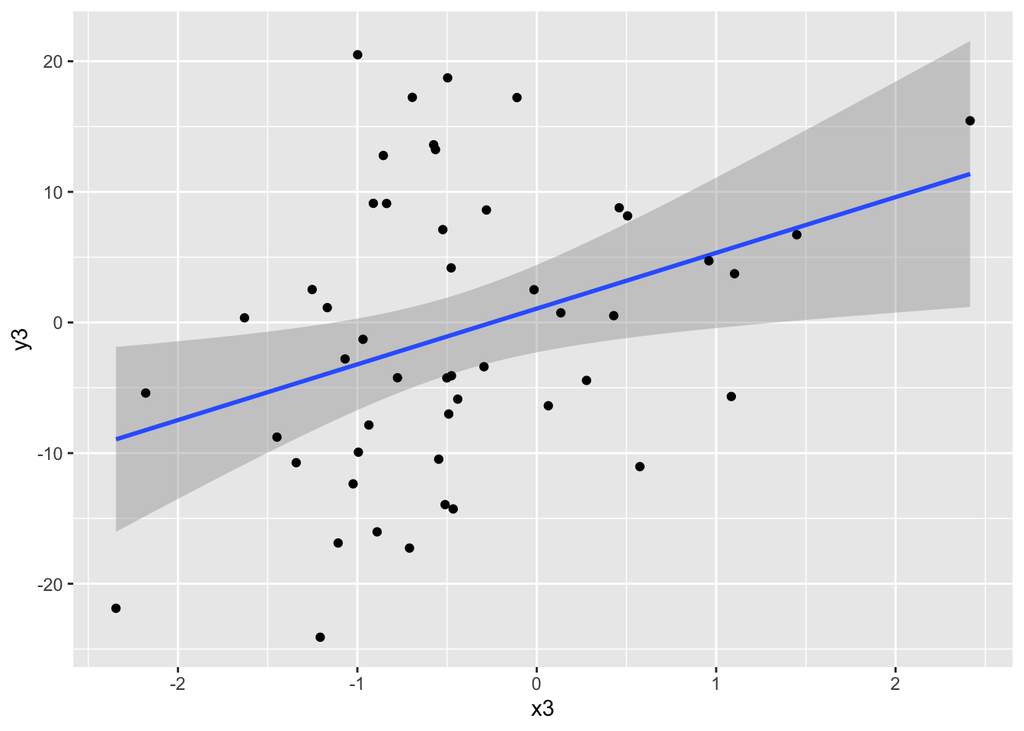

```r
set.seed(1234)
x3<-rnorm(50)
y3<- 5*x3 + rnorm(50, sd = 10)

dat.tutorial3 <- data.frame(x3,y3)

ggplot(dat.tutorial3, aes(x = x3, y = y3)) +
  geom_smooth(method = "lm") + geom_point()
```

Check your answer:

```r
cor.test(dat.tutorial3$x3, dat.tutorial3$y3)
```

```
##
##  Pearson's product-moment correlation
##
## data:  dat.tutorial3$x3 and dat.tutorial3$y3
## t = 2.5274, df = 48, p-value = 0.01484
## alternative hypothesis: true correlation is not equal to 0
## 95 percent confidence interval:
##  0.07114562 0.56697017
## sample estimates:
##       cor
## 0.3427066
```

Play around with this code, and see what happens when you change either the slope or the error (standard deviation) of y3. Based on these outputs, what do you conclude?

**Linking to the formula:**

The formula for Pearson’s correlation, $\rho$ (pronounced ‘row’) is:

$$\rho = \frac{cov(X, Y)}{\sigma_{x}
\sigma_{y}}$$

This is the covariance between X and Y divided by the product of their standard deviation.

More formally:

$$\rho= \frac{\sum(x_{i} - \bar x)(y_{i}
- \bar y)}{\sqrt\sum(x_{i} - \bar x)^2\sum(y_{i} - \bar y)^2}$$

**Comprehension Check: How can we connect these formulas to our simulations above? Think about what happens in our first simulation where *y had no error.***

In summary, correlation coefficients take into account both the slope (covariance) and the error terms (standard deviations) of the two variables.